# QHCI 2021 - Project 2

Tobias Boner (17-707-878)

12.05.2021

This project is based on the paper *[How We Type: Movement Strategies and Performance in Everyday Typing](https://dl.acm.org/doi/10.1145/2858036.2858233)*. We used the data set the authors have provided within the course of their study. The aim of the data analysis will be to answer the following to research questions (*RQ*):

- *RQ1: Do overall typing speed differ between touch-typist and non-touchtypist?*
- *RQ2: How much does the result from RQ1 influenced by whether the participants type known-words or random string?*

The analysis will base on the **within-subject design** of the study including **one independent variable *(IV)*** that has **three levels**. The **IV *stimulus tpye*** refers to the type of string users had to type in for the transcription and has three levels:

- *sentences*: easy regular sentences
- *random*: random sequences of letters
- *mix*: a mix of the two other conditions

For the experiments they used a **randomized order** for the three *stimulus types*.

# Data Analysis

Within this part we will analyze the data set and try to answer the two research questions.

## Setup

Before we can jump in the analysis we start with setting up the required dependencies for this R notebook.

```r
# define packages
required_packages <- c("tidyverse", "readr", "ggplot2", "stringr")

# install packages when they are not already included
install.packages(setdiff(required_packages, rownames(installed.packages())))
```

Then load the packages to finish the setup

```r
# load the packages
library(tidyverse)
library(readr)
library(ggplot2)
library(stringr)
```

## Data Processing

Next we can start with the data processing. First of, we define a helper function `read_log_files` that will help read in all the different log files.

```r
# Regular expression to help parse the log files
regex_parse <- "User(\\d+)_T(\\d+)_(.*).csv"

# helper function to read in log files
read_log_files <- function(fileName){
  csv_data <- read_csv(str_c('./log/',fileName)) %>%
      mutate(length = str_length(stimulus)) %>%
      group_by(stimulus_index) %>%
      summarise(wpm = (as.double(max(length)-1)/5)/ as.double(max(input_time_ms)) * 60000, length = max(length)) %>%
      mutate(user_id = as.numeric(str_replace(fileName, regex_parse, "\\1")), condition = str_replace(fileName, regex_parse, "\\3"))
    return(csv_data)
}
```

Thereafter, we define all the existing log files (`log_files`) and and the csv containing the participant information (`participant_info`).

```r
# list of all log files
log_files <- list.files('./log')

# file that includes the participant information
participant_info <- read_csv("participant_info.csv")

# backup file that is already processed
combined_log_background <- read_csv(("combined_log_background.csv"))
```

Now we are ready to process the log files and create the data we need.

```r
# data wrangling
data <- as_tibble_col(lapply(log_files, read_log_files), col='nested') %>%
        unnest(nested) %>% merge(y=participant_info, by='user_id', all.x = TRUE ) %>%
        mutate(typing_style = if_else(is_touchtypist, 'Non-touchtypist', 'Touchtypist')) %>%
        select(-is_touchtypist, -length)

# ? TODO add comment
data_with_cond <- data %>% mutate(condition = factor(condition, levels = c("Sentences", "Mix", "Random")), typing_style = factor(typing_style, levels = c("Non-touchtypist", "Touchtypist")))
```

> Note that the *IV stimulus type* is now referred to as *condition* in our data set with the same three levels (*Sentences, Random, Mix*). The *typing style* will still be referred to as *typing style*.

## Data Exploration and Description

After having processed the data, we now want to inspect and explore it to get a better overview. To do so we can describe its basic properties.

### General Information

Thus, it is a good idea to have a quick look at the data by using `head(data)`.

|  | user_id | stimulus_index | wpm | condition | typing_style |
| --- | --- | --- | --- | --- | --- |
| 1 | 5307 | 0 | 52.60274 | Sentences | Non-touchtypist |
| 2 | 5307 | 1 | 73.73764 | Sentences | Non-touchtypist |
| 3 | 5307 | 2 | 76.96419 | Sentences | Non-touchtypist |
| 4 | 5307 | 3 | 88.76365 | Sentences | Non-touchtypist |
| 5 | 5307 | 4 | 66.34722 | Sentences | Non-touchtypist |
| 6 | 5307 | 5 | 87.24389 | Sentences | Non-touchtypist |

Next we check the structure of the data object with `str(data)` and can see the data types of each column.

```
## 'data.frame':    4493 obs. of  5 variables:
##  $ user_id       : num  5307 5307 5307 5307 5307 ...
##  $ stimulus_index: num  0 1 2 3 4 5 6 7 8 9 ...
##  $ wpm           : num  52.6 73.7 77 88.8 66.3 ...
##  $ condition     : chr  "Sentences" "Sentences" "Sentences" "Sentences" ...
##  $ typing_style  : chr  "Non-touchtypist" "Non-touchtypist" "Non-touchtypist" "Non-touchtypist" ...
```

Our data set contains 5 columns (*user_id, stimulus_index, wpm, condition, typing_style*) and 4493 rows for 30 different users.

### Descriptive Statisctics

Now that we know how the data looks and what type of data it contains, we can have a look at the data itself. To get a broad overview of the data we use the `summary` function.

```
##     user_id       stimulus_index      wpm           condition
##  Min.   :  5307   Min.   : 0.0   Min.   :  6.389   Length:4493
##  1st Qu.:221357   1st Qu.:12.0   1st Qu.: 29.197   Class :character
##  Median :376930   Median :24.0   Median : 40.495   Mode  :character
##  Mean   :399581   Mean   :24.5   Mean   : 43.432
##  3rd Qu.:535385   3rd Qu.:37.0   3rd Qu.: 56.112
##  Max.   :934313   Max.   :49.0   Max.   :109.331
##  typing_style
##  Length:4493
##  Class :character
##  Mode  :character
##
##
##
```

In order to answer the research questions we will now have a look at the *words per minute (wpm)* first with regards to the *typing style* (RQ1) and then in connection with the different *conditions* (RQ2). To support this process we will also create suitable visualizations for the data sets.

#### **RQ1 - words per minute (wpm) by typing styles**

First we create a violin plot that includes boxplots for *words per minute (wpm)* by the *typing styles* of users.

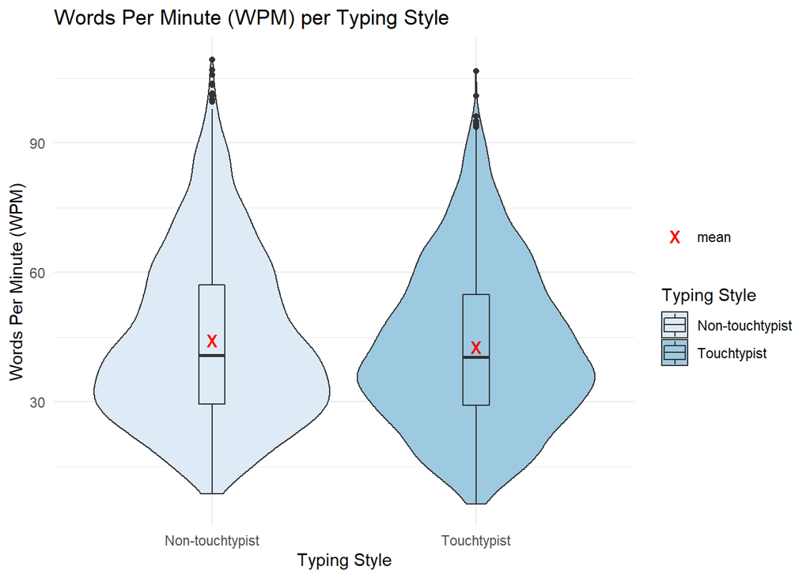

Out of this first visualization, we can already imply that there is no big difference between the two *typing styles* with regards to *words per minutes (wpm)*. This is also shown in the numbers.

Skewness is a commonly used measure of the symmetry of a statistical distribution. A negative skewness indicates that the distribution is left skewed and the mean of the data (average) is less than the median value

**Non-Parametric Statisctics**

- Median:
  - On the one hand Non-touchtypist has a `median` of 40.7680945 *wpms* and on the other hand Touchtypist has a `median` of 40.3754218 *wpms*.
- Min and Max Values:
  - For the `min` values Non-touchtypist has a value of 8.7412587 *wpms* and Touchtypist has a value of 6.3890959 *wpms*.
  - Regarding the `max`values Non-touchtypist has a value of 109.33082 *wpms* and Touchtypist has a value of 106.5614208 *wpms*.
- Interquartile Range (IQR) :
  - The `IQR` of Non-touchtypist amounts to 27.6594083 and on the `IQR` for Touchtypist to 25.7998562.

These non-parametric statistical properties confirm the initial impressions from the visualization above that there are only slight differences between the two *typing styles* with regards to *words per minute (wpm)*. The `median`, `min`, `max`, as well as the `IQR` reveal only small differences.

**Parametric Statistics**

- Mean:
  - On the one hand Non-touchtypist has a `mean` of 44.2501875 *wpms* and on the other hand Touchtypist has a `mean` of 42.715547 *wpms*.
- Spread:
  - For the variance (`var`), Non-touchtypist has a value of 375.0135804 and Touchtypist has a value of 338.9006071.
  - Regarding the standard deviation, (`sd`) Non-touchtypist accounts to 19.3652674 and Touchtypist to 18.4092533.

These numbers shows that also the parametric statistical properties in the form of `mean`, variance(`var`) and standard deviation(`sd`) are quite similar.

Now that we have concrete numbers for both the `mean` and the `median` for *typing styles* by *wpms* we can make a statement about the distributions of the data and their shapes. For Non-touchtypist that have a `mean` of 44.2501875 *wpms* and a `median` of 40.7680945 *wpms*, the shape is skewed right. The same applies For Touchtypist that have a `mean` of 42.715547 *wpms* and a `median` of 40.3754218 *wpms*, where the shape is skewed-right.

Eventually, the numbers confirmed the initial impressions from the visualizations that there is not a big difference between the two *typing styles* with regards to the *wpms*. But there is a slight difference for example in the distribution and shape of the data.

#### Histograms

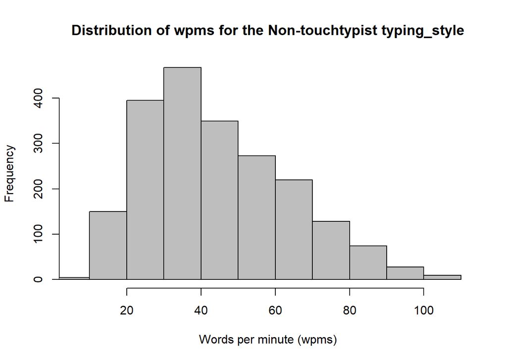

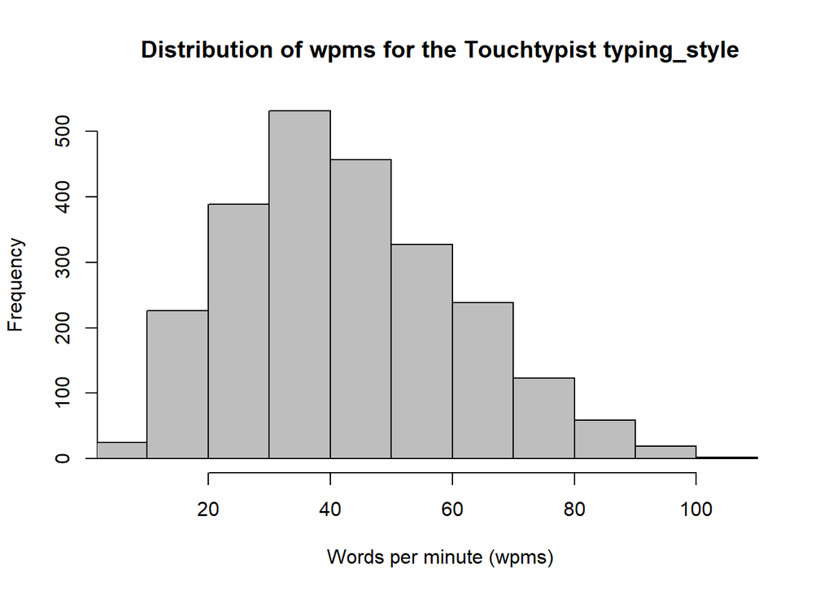

#### **RQ2 - words per minute (wpm) by condition (stimulus type)**

With RQ2 in mind we create the same plot again for *words per minute (wpm)* by the different *conditions*.

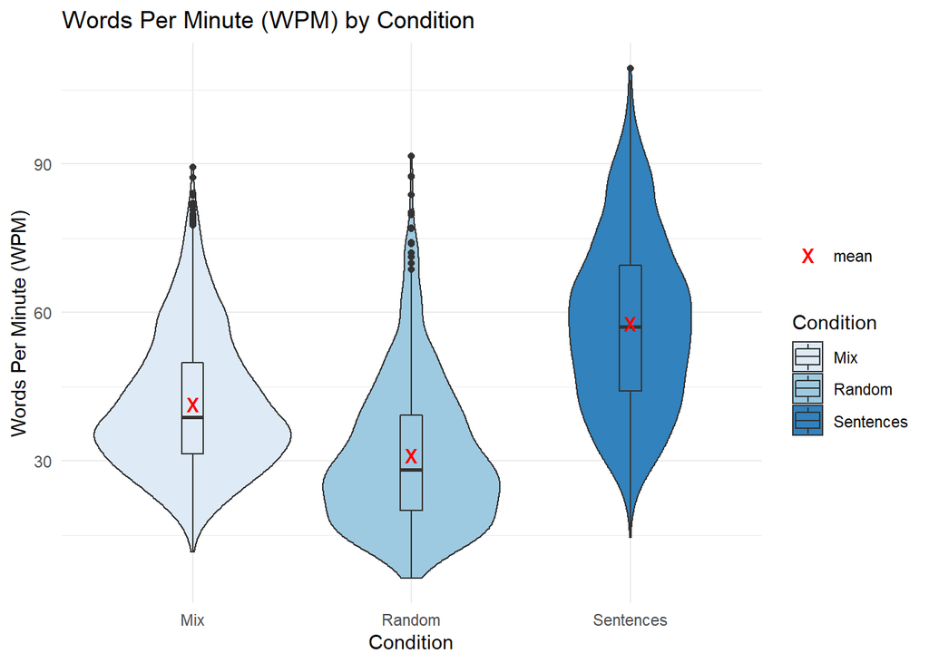

In contrast to the visualization before, in this case we immediately see that the violin and boxplots appear quite different with regards to the *conditions* and *word per minutes (wpm)*. Hence we should again have a closer look at the numbers again.

**Non-Parametric Statistics**

- Median:
  - Mix has a `median` of 38.7625792 *wpms*, Random has a `median` of 28.2885431 *wpms* and Sentences has a `median` of 57.167605 *wpms*.
- Min and Max Values:
  - For the `min` values Mix has a value of 11.6360502 *wpms*, Random has a value of 6.3890959 *wpms* and Sentences has a value of 14.5406477 *wpms*.
  - Regarding the `max`values Mix has a value of 89.2789012 *wpms*, Random has a value of 91.6030534 *wpms* and Sentences has a value of 109.33082 *wpms*.
- Interquartile Range (IQR) :
  - The `IQR` of Mix amounts to 18.3630421, the `IQR` for Random to 19.2403134 and on the `IQR` for Sentences to 25.3715642.

At this point we can already say that there are obvious differences between the *conditions*.

**Parametric Statistics**

- Mean:
  - For the Mix users have a `mean` of 41.4473594 *wpms*, forRandom a `mean` of 31.0927423 *wpms* and forSentences has a `mean` of 57.7361984 *wpms*.
- Spread:
  - For the variance (`var`), Mix has a value of 187.2133526, Random has a value of 217.1712564 and Sentences has a value of 303.6272773.
  - Regarding the standard deviation, (`sd`) Mix accounts to 13.682593, Random to 14.7367315 and Sentences to 17.4249039.

Looking at the concrete numbers for both the `mean` and the `median` for *condtitions* by *wpms* this gets clearer:

- Condition Mix:
  - For Mix that have a `mean` of 41.4473594 *wpms* and a `median` of 38.7625792 *wpms*.
- Condition Random:
  - The same applies for Random with a `mean` of 31.0927423 *wpms* and a `median` of 28.2885431 *wpms*.
- Condition Sentences:
  - For Sentences the `mean` is 57.7361984 *wpms* and the `median` is 57.167605 *wpms*.

#### Histograms

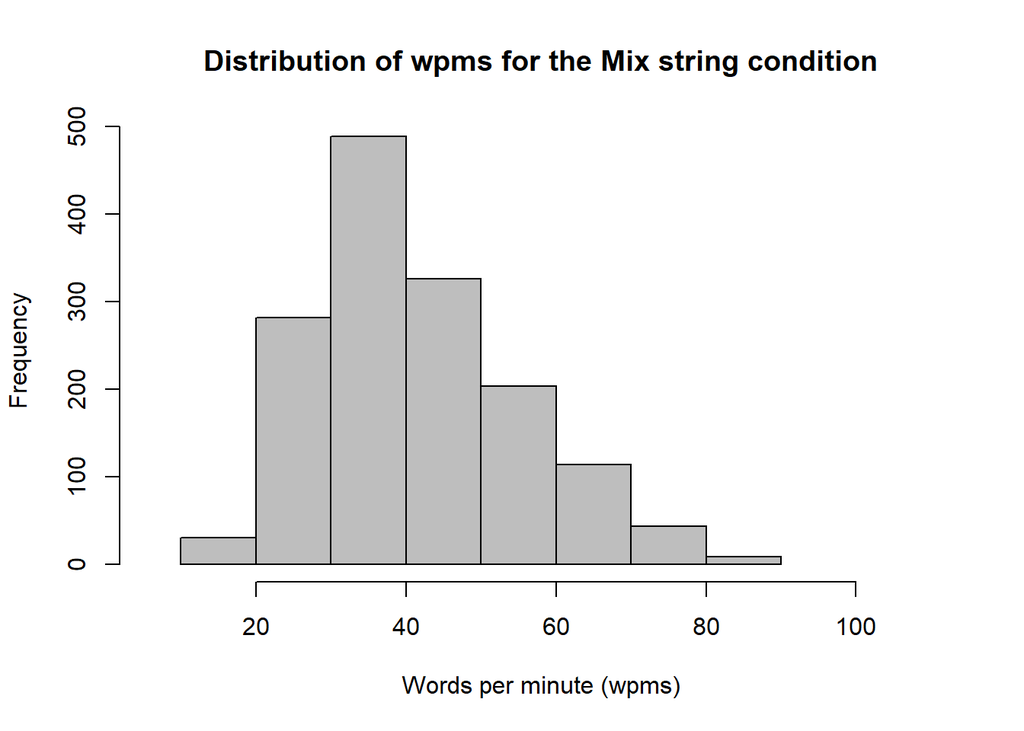

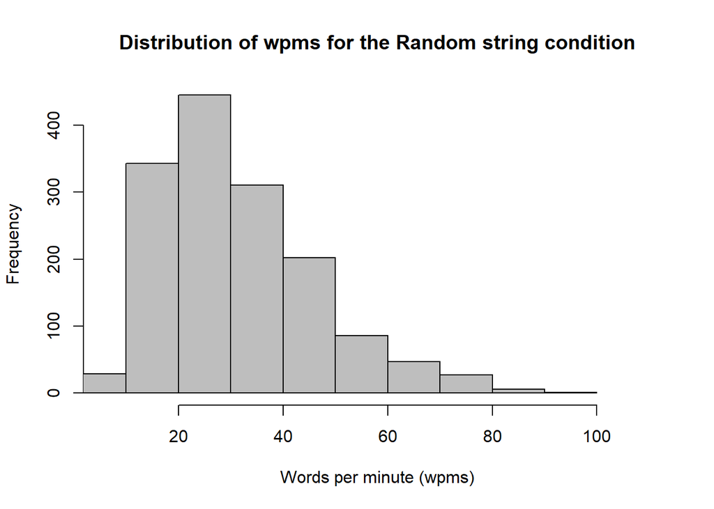

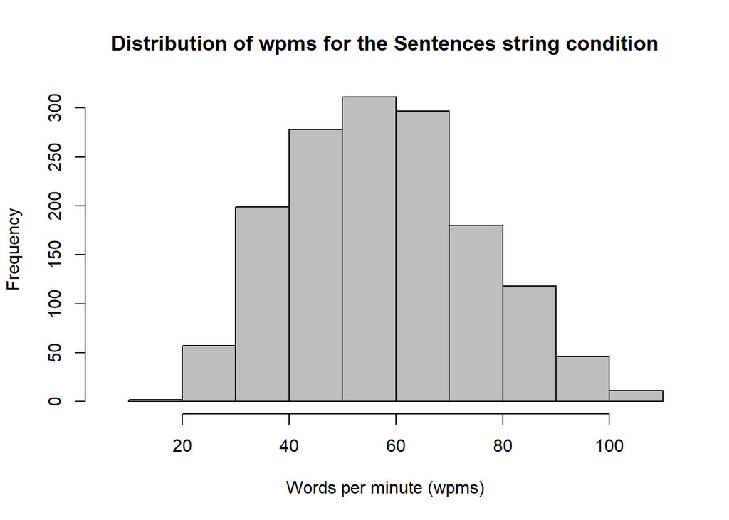